# What's the best way to deal with a future pandemic?

By: Samuel Rodriguez

# Introduction:

Coronavirus disease (COVID-19) is an infectious disease that rapidly spread across the world. It is a respiratory illness that is spread from person to person though close contact. COVID has completely changed the world forever and has affected every single individual differently. Currently COVID has infected over 163.61 million people worldwide with 3.39 million people dying from the virus. Now that we are hopefully nearing the end of the pandemic, it is important to look at who handled the virus the best in order to see how to deal with future pandemics that are bound to happen. In fact, epidemics and even pandemics are becoming increasingly more common with examples such as, Ebola, Zika, SARS, H1N1 flu, and now COVID.

Dataset: I used the website linked in the rubric to find my datasets (https://datascience.nih.gov/covid-19-open-access-resources). I chose to use the Amazon Web Services (AWS) data. This is "a centralized repository of up-to-date and curated datasets related to the spread and characteristics of and COVID-19." Then, I decided to use one dataset that gathered information on the United States at a state level and my other dataset which gathered information on the world at a country level. This gets me all the information I will need.

# Deaths Vs Time

I will start by checking how different USA states handled the virus. To do this, I will check the amount of deaths caused by the virus across time. This will tell us which states handled the COVID the best and which states handled COVID the worst and will tell us the correct steps each state should take in preventing a future pandemic.

Before I can began plotting, I need to import all the packages and load in my datasets into dataframes. Then, I converted the date columns of each of my dataframes into date types. This makes plotting the dates on my x-axis look nicer as python handles datetime objects differently than strings.

```python
import pandas as pd
import matplotlib.pyplot as plt
from sklearn import linear_model
import numpy as np
```

```python
# Reads in CSV files converting them into dataframes
df_USA = pd.read_csv("https://covid19-lake.s3.us-east-2.amazonaws.com/rearc-covid-19-nyt-data-in-usa/csv/us-states/us-states.csv")
df_World = pd.read_csv("https://covid19-lake.s3.us-east-2.amazonaws.com/rearc-covid-19-world-cases-deaths-testing/csv/covid-19-world-cases-deaths-testing.csv")

# Converts date columns to date type.
df_USA['date'] = pd.to_datetime(df_USA['date'])
df_World['date'] = pd.to_datetime(df_World['date'])

df_World.head()
```

|  | iso_code | continent | location | date | total_cases | new_cases | new_cases_smoothed | total_deaths | new_deaths | new_deaths_smoothed | total_cases_per_million | new_cases_per_million | new_cases_smoothed_per_million | total_deaths_per_million | new_deaths_per_million | new_deaths_smoothed_per_million | reproduction_rate | icu_patients | icu_patients_per_million | hosp_patients | hosp_patients_per_million | weekly_icu_admissions | weekly_icu_admissions_per_million | weekly_hosp_admissions | weekly_hosp_admissions_per_million | new_tests | total_tests | total_tests_per_thousand | new_tests_per_thousand | … |
| --- | --- | --- | --- | --- | --- | --- | --- | --- | --- | --- | --- | --- | --- | --- | --- | --- | --- | --- | --- | --- | --- | --- | --- | --- | --- | --- | --- | --- | --- | --- |
| 0 | AFG | Asia | Afghanistan | 2020-02-24 | 1.0 | 1.0 | NaN | NaN | NaN | NaN | 0.026 | 0.026 | NaN | NaN | NaN | NaN | NaN | NaN | NaN | NaN | NaN | NaN | NaN | NaN | NaN | NaN | NaN | NaN | NaN | … |
| 1 | AFG | Asia | Afghanistan | 2020-02-25 | 1.0 | 0.0 | NaN | NaN | NaN | NaN | 0.026 | 0.000 | NaN | NaN | NaN | NaN | NaN | NaN | NaN | NaN | NaN | NaN | NaN | NaN | NaN | NaN | NaN | NaN | NaN | … |
| 2 | AFG | Asia | Afghanistan | 2020-02-26 | 1.0 | 0.0 | NaN | NaN | NaN | NaN | 0.026 | 0.000 | NaN | NaN | NaN | NaN | NaN | NaN | NaN | NaN | NaN | NaN | NaN | NaN | NaN | NaN | NaN | NaN | NaN | … |
| 3 | AFG | Asia | Afghanistan | 2020-02-27 | 1.0 | 0.0 | NaN | NaN | NaN | NaN | 0.026 | 0.000 | NaN | NaN | NaN | NaN | NaN | NaN | NaN | NaN | NaN | NaN | NaN | NaN | NaN | NaN | NaN | NaN | NaN | … |
| 4 | AFG | Asia | Afghanistan | 2020-02-28 | 1.0 | 0.0 | NaN | NaN | NaN | NaN | 0.026 | 0.000 | NaN | NaN | NaN | NaN | NaN | NaN | NaN | NaN | NaN | NaN | NaN | NaN | NaN | NaN | NaN | NaN | NaN | … |

```python
# Pivots the dataframe to make data graphable
df_USA2 = df_USA.pivot(index = 'date', columns = 'state', values = 'deaths')

# Creates a new dataframe with only the necessary columns
df_USA2 = df_USA2[["Maryland", "New York", "California", "Texas", "Hawaii", "Vermont", "South Dakota"]]
df_USA2.head()
```

| state date | Maryland | New York | California | Texas | Hawaii | Vermont | South Dakota |
| --- | --- | --- | --- | --- | --- | --- | --- |
| 2020-01-21 | NaN | NaN | NaN | NaN | NaN | NaN | NaN |
| 2020-01-22 | NaN | NaN | NaN | NaN | NaN | NaN | NaN |
| 2020-01-23 | NaN | NaN | NaN | NaN | NaN | NaN | NaN |
| 2020-01-24 | NaN | NaN | NaN | NaN | NaN | NaN | NaN |
| 2020-01-25 | NaN | NaN | 0.0 | NaN | NaN | NaN | NaN |

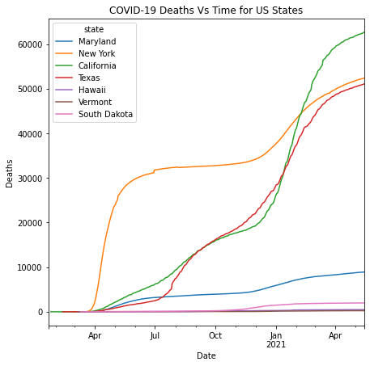

```python
# Plots the data
ax = df_USA2.plot(figsize = (7,7), title = "COVID-19 Deaths Vs Time for US States")

# Sets the x and y axis labels and shows the plot
ax.set(xlabel = "Date", ylabel = "Deaths")
plt.show()
```

From the plot we can see that New York, California, and Texas had the most COVID deaths by a large amount. This contrasts Hawaii and Vermont who have such low number of deaths that their lines look straight.

Note: Didn't include China due to lack of accurate data.

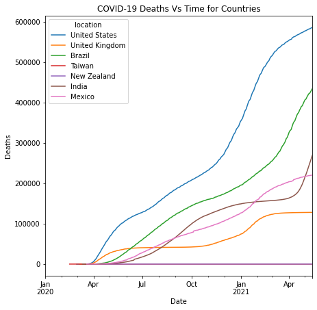

```python
# Pivots the dataframe to make data graphable
df_World2 = df_World.pivot(index = 'date', columns = 'location', values = 'total_deaths')

# Creates a new dataframe with only the necessary columns
df_World2 = df_World2[["United States", "United Kingdom", "Brazil", "Taiwan", "New Zealand", "India", "Mexico"]]

# Plots the data
ax = df_World2.plot(figsize = (7,7), title= "COVID-19 Deaths Vs Time for Countries")

# Sets the x and y axis labels and shows the plot
ax.set(xlabel = "Date", ylabel = "Deaths")
plt.show()
```

Looking at the graph, we can see that the United States and Brazil had the most COVID deaths and New Zealand and Taiwan had the least amount of deaths. Although this is true, we can't definitively say this is because of the way they handled the virus because of the population sizes. The USA and UK have much larger populations than New Zealand and Taiwan so it would make sense that they have more deaths in the country. The same can be said about New York and California since these states have large populations compared to other states. In order to fix this, I will check the mortality rates of each state/country.

# Mortality Rates

The mortality rate is the measure of the number of deaths in a population, scaled to the size of that population, per unit of time. This will give us an accurate representation of how COVID has affected each state/country. In order to find the mortality rate, you divide the total amount of deaths caused by the virus by the population and then multiply this number by 1000.

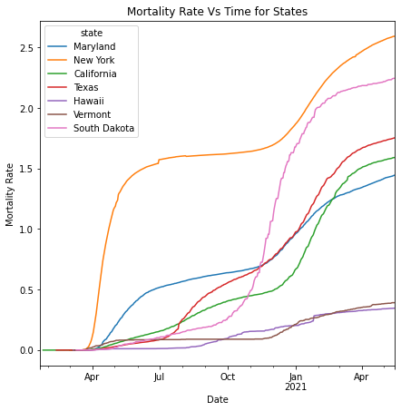

```python
# Updates columns with mortality rate of every state replacing the number of deaths per state
# Note: Not going to be 100% accurate since I used a rough estimate of the population at the end of the year instead of the current population per day, which I don't have.
df_USA2['Maryland'] = (df_USA2['Maryland']/ 6177224) * 1000
df_USA2['New York'] = (df_USA2['New York']/ 20201249) * 1000
df_USA2['California'] = (df_USA2['California']/ 39370000) * 1000
df_USA2['Texas'] = (df_USA2['Texas']/ 29145505) * 1000
df_USA2['Hawaii'] = (df_USA2['Hawaii']/ 1407006) * 1000
df_USA2['Vermont'] = (df_USA2['Vermont']/ 643077) * 1000
df_USA2['South Dakota'] = (df_USA2['South Dakota']/ 886667) * 1000

# Plots the data
ax = df_USA2.plot(figsize = (7,7), title= "Mortality Rate Vs Time for States")

# Sets the x and y axis labels and shows the plot
ax.set(xlabel = "Date", ylabel = "Mortality Rate")
plt.show()
```

Looking at the plot, we can see that New York and South Dakota had the highest mortality rates. This makes sense since these were the states that were slow to respond to COVID with South Dakota never even issuing stay-at-home orders or mask mandates. Vermont and Hawaii had the lowest mortality rates by a large margin. This shows that for a future pandemic states should respond very quickly as Vermont and Hawaii did.

Next, I will be checking the mortality rates of the countries chosen.

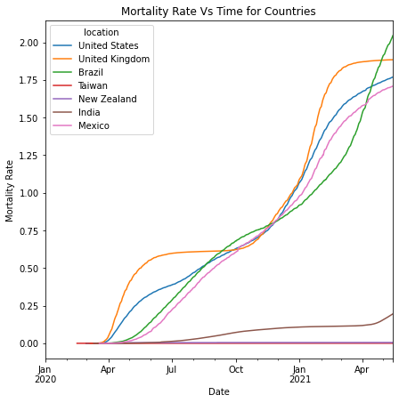

```python
# Creates a new column with mortality rate of every country
df_World['Mortality Rate'] = (df_World['total_deaths']/ df_World['population']) * 1000

# Pivots the dataframe to make data graphable
df_World2 = df_World.pivot(index = 'date', columns = 'location', values = 'Mortality Rate')

# Creates a new dataframe with only the necessary countries
df_World2 = df_World2[["United States", "United Kingdom", "Brazil", "Taiwan", "New Zealand", "India", "Mexico"]]

# Plots the data
ax = df_World2.plot(figsize = (7,7), title= "Mortality Rate Vs Time for Countries")

# Sets the x and y axis labels and shows the plot
ax.set(xlabel = "Date", ylabel = "Mortality Rate")
plt.show()
```

Looking at the plot, we can see which countries did a good job of containing COVID-19 and which countries let it run rampant. In the plot, we can see that Taiwan and New Zealand have extremely low mortality rates. This makes sense since these are the countries that took COVID very seriously early on with travel restrictions, full national lockdowns, and aggressive testing/contact tracing. This directly contrasts countries that didn't take COVID seriously. Examples of these are the USA, UK, and Brazil who refused to acknowledge COVID for the longest time with Brazil never even having a national lockdown. This proves that our hypothesis is correct and countries that took action immediately to prevent the virus from spreading had a much less mortality rate than countries who pretended it didn't exist. This means for a further pandemic it is extremely important to take swift, immediate action.

# India Spike

```python
# Only includes India data, deleting everything else
df_India = df_World.loc[df_World['location'] == 'India']

# Pivots the dataframe to make data graphable
df_India = df_India.pivot(index = 'date', columns = 'location', values = 'new_cases')

# Converts the date column into a regular colummn so it can be plotted
df_India.reset_index(inplace = True)

# Renames India column. Makes plot look nicer/makes more sense.
df_India = df_India.rename(columns = {"India": "Cases per Day"})

# Converts date column back to str type. This deletes the time on the xticks when graphing since its not needed and all 0:00.
df_India["date"] = df_India["date"].astype(str)

df_India.head()
```

| location | date | Cases per Day |
| --- | --- | --- |
| 0 | 2020-01-30 | 1.0 |
| 1 | 2020-01-31 | 0.0 |
| 2 | 2020-02-01 | 0.0 |
| 3 | 2020-02-02 | 1.0 |
| 4 | 2020-02-03 | 1.0 |

I started by creating by own India dataframe that I will use to plot the number of new cases per day. This will show us when the spike occured and will tell us why. I also cleaned the dataframe and made it ready to plot. I changed the datatype column back into strings so the time isn't printing which makes my bar plot not as cluttered and prints correctly.

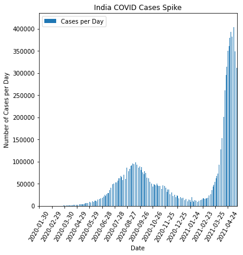

```python
# Plots the data
ax = df_India.plot(figsize = (6,6), x = 'date', y = 'Cases per Day', title= "India COVID Cases Spike" , kind = "bar")

# Set the x and y axis labels
ax.set(xlabel = "Date", ylabel = "Number of Cases per Day")

# Fixes xticks displaying only a couple. Too many xticks causes an error if this isn't done
p = np.arange(len(df_India['date']))
plt.xticks(p[::30], df_India['date'].values[::30], rotation = 60)
plt.show()
```

Looking at the barplot, we can see that the massive spike of new cases occured at approximately the beginning of March 2021. This is when India starting to reopen and believed the virus was over with, however, as seen in the barplot this couldn't be further from the truth. Looking at what has occurred in India, it is important that a country doesn't open too early. If India took another couple of months or gradually opened instead of having huge gatherings at public festivals and election rallies the massive spike could have been prevented. Countless lives could have been saved.

# Vaccinations

Finally, I will finish by checking the effect vaccines have on a country. It is believed that as more people get vaccinated the number of COVID cases will rapidly fall.

```python
# Creates a new % vaccinated column by divided the number of fully vaccinated people by the population and multiplying this number by 100
df_World['Percentage Vaccinated'] = (df_World['people_fully_vaccinated']/ df_World['population']) * 100

# Creates 7 seperate dataframes for each country chosen.
df_Us = df_World3.loc[df_World['location'] == 'United States']
df_Uk = df_World3.loc[df_World['location'] == 'United Kingdom']
df_Braz = df_World3.loc[df_World['location'] == 'Brazil']
df_Tai = df_World3.loc[df_World['location'] == 'Taiwan']
df_NZ = df_World3.loc[df_World['location'] == 'New Zealand']
df_Ind = df_World3.loc[df_World['location'] == 'India']
df_Mex = df_World3.loc[df_World['location'] == 'Mexico']

# Deletes all the rows for each df up until January 1,2021. This is because vaccines weren't admitted until 2021 so the 2020 info is useless.
df_Uk = df_Uk.iloc[308:]
df_Us = df_Us.iloc[308:]
df_Braz = df_Braz.iloc[308:]
df_Tai = df_Tai.iloc[308:]
df_NZ = df_NZ.iloc[308:]
df_Ind = df_Ind.iloc[308:]
df_Mex = df_Mex.iloc[308:]

# Gets the necessary columns that I will be graphing
df_Us = df_Us[["date", "Percentage Vaccinated"]]
df_Uk = df_Uk[["date", "Percentage Vaccinated"]]
df_Braz = df_Braz[["date", "Percentage Vaccinated"]]
df_Tai = df_Tai[["date", "Percentage Vaccinated"]]
df_NZ = df_NZ[["date", "Percentage Vaccinated"]]
df_Ind = df_Ind[["date", "Percentage Vaccinated"]]
df_Mex = df_Mex[["date", "Percentage Vaccinated"]]

# Merges all 7 dataframes into 1 final graphable dataframe. It renames the columns as I add.
fin = df_Us.merge(df_Uk, how = 'inner', on = ['date'])
fin = fin.rename(columns = {"Percentage Vaccinated_x": "USA", "Percentage Vaccinated_y": "UK"})
fin = fin.merge(df_Braz, how = 'inner', on = ['date'])
fin = fin.merge(df_Tai, how = 'inner', on = ['date'])
fin = fin.rename(columns = {"Percentage Vaccinated_x": "Brazil", "Percentage Vaccinated_y": "Taiwan"})
fin = fin.merge(df_NZ, how = 'inner', on = ['date'])
fin = fin.merge(df_Ind, how = 'inner', on = ['date'])
fin = fin.rename(columns = {"Percentage Vaccinated_x": "New Zealand", "Percentage Vaccinated_y": "India"})
fin = fin.merge(df_Mex, how = 'inner', on = ['date'])
fin = fin.rename(columns = {"Percentage Vaccinated": "Mexico"})

fin.head()
```

|  | date | USA | UK | Brazil | Taiwan | New Zealand | India | Mexico |
| --- | --- | --- | --- | --- | --- | --- | --- | --- |
| 0 | 2021-01-01 | NaN | NaN | NaN | NaN | NaN | NaN | NaN |
| 1 | 2021-01-02 | NaN | NaN | NaN | NaN | NaN | NaN | NaN |
| 2 | 2021-01-03 | NaN | 0.03241 | NaN | NaN | NaN | NaN | NaN |
| 3 | 2021-01-04 | NaN | NaN | NaN | NaN | NaN | NaN | NaN |
| 4 | 2021-01-05 | NaN | NaN | NaN | NaN | NaN | NaN | NaN |

I created a dataframe that has the dates and percentages of fully vaccinated people by country. I had to rename as I merged because if I renamed at the end I would have 4 "Percentage Vaccinated_x" columns and 3 "Percentage Vaccinated_y" columns which would be impossible to rename. In hindsight, I should have just pivoted the dataframe as I had done previously, but I realized this after I finished.

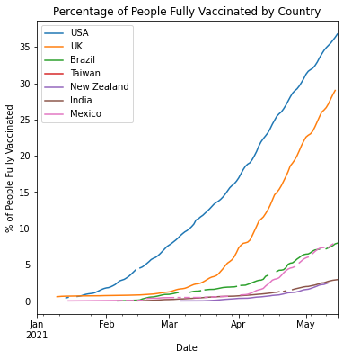

```python
# Plots the data
ax = fin.plot(figsize = (6,6), x = "date", title = "Percentage of People Fully Vaccinated by Country")
#df_Uk.plot(x = "date", y = ["new_cases_per_million", "new_vaccinations_smoothed_per_million"], ax = ax)

# Sets the x and y axis labels and shows the plot
ax.set(xlabel = "Date", ylabel = "% of People Fully Vaccinated")
plt.show()
```

Looking at the plot, we can see that USA and UK are leading the other countries with the most fully vaccinated people. The UK has over 25% of its population fully vaccinated whereas the USA has over 35% of its population fully vaccinated. Next, I will check the number of new cases per day for each of these countries to see if theres a correlation between vaccines and number of new cases.

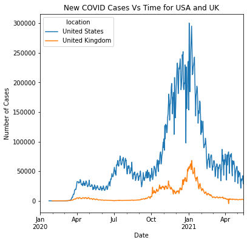

```python
# Pivots the dataframe to make data graphable
df_World4 = df_World.pivot(index = 'date', columns = 'location', values = 'new_cases')

# Creates a new dataframe with only the necessary countries
df_World4 = df_World4[["United States", "United Kingdom"]]

# Plots the data
ax = df_World4.plot(figsize = (6,6), title= "New COVID Cases Vs Time for USA and UK")

# Sets the x and y axis labels and shows the plot
ax.set(xlabel = "Date", ylabel = "Number of Cases")

plt.show()
```

Looking at the plot, we can see that the number of new COVID cases rapidly drops for each country at about January 2021. This is exactly when people started to get vaccinated in each respective country. This shows that there is a correlation between new cases and vaccines. This means an individual should get vaccinated as soon as possible to stop the spread of the virus.

# Conclusion

Overall, states/countries that took immediate, swift action to try and prevent the spread of COVID had a much lower infection rate than states/countries that chose to ignore it. This includes national lockdowns, mask mandates, travel restrictions, border closers, contact tracing, and finally stay-at-home orders. These laws and restrictions implemented early allows countries to get back to normal life way sooner than countries who ignored the virus and are still dealing with it today. For example, countries such as New Zealand have already returned back to normal life months ago as compared to the USA who is just starting to return back to normal life now. This shows that it is essential to rapidly respond to a future pandemic that is bound to happen. Not only is it important to respond early, but the state/country must not let up restrictions until the pandemic is fully over. As seen in California and India who had a good start to containing the virus, but let up too early and had masssive outbreaks. Finally, it is important to get vaccinated as soon as possible to further stop the spread of the virus.

# Resources used:

These are the links that I used to learn more about the affects COVID had on each USA state and country.

- https://www.mdlinx.com/article/best-and-worst-states-in-controlling-covid-19/1ovlYhVeCLLk1MoU45PZrs
- https://www.bloomberg.com/news/articles/2020-05-28/why-was-new-york-hit-so-badly-with-covid-19
- https://www.theguardian.com/us-news/2020/dec/28/how-california-went-from-leader-covid-fight-despair
- https://www.movehub.com/blog/best-and-worst-covid-responses/
- https://www.france24.com/en/asia-pacific/20210128-study-ranks-new-zealand-covid-19-response-best-brazil-worst-us-in-bottom-five
- https://www.nationalgeographic.com/science/article/how-indias-second-wave-became-the-worst-covid-19-surge-in-the-world